# Evolving Ideas and Narratives: Analyzing Raymond Moley’s Themes, Keywords, and Sentiment Over Time

Teona Goderdzishvili

December 3, 2024

**Research Questions**

**1.** How have Moley’s ideas and themes evolved over time?

**2.** How has the public perception of Moley, as reflected through descriptive language, changed throughout the years?

I aim to analyze how Moley’s most influential ideas developed and transformed across his work. Additionally, I want to understand how he was portrayed in contemporary papers and documents, focusing on the descriptive language and narratives used to characterize him. My methodological approach uses R for:

- Term frequency analysis to identify key concepts and recurring themes
- Keyword extraction to track specific ideas
- Sentiment analysis to evaluate the emotional tone of the texts
- Temporal trend visualization using ggplot to map changes in sentiment and themes over time

The research combines computational text analysis with historical context to provide insights into both Moley’s intellectual evolution and his public reception.

**Preliminary Work on Codebook**

**Economic Policy:** I’ll track the frequency and context of key terms related to Moley’s economic policy ideas, such as “new deal” and “reform”. This will help me understand the evolution of his policy positions over time.

**Ideological Stances:** I’ll analyze how Moley and his circle’s ideological stances, such as “liberalism” and “conservatism”, are portrayed in the articles. I’ll note if there are any significant changes or shifts in their positions over the years.

**Character Names and Descriptions:** The articles mention of some of the key names of the state actors. I will gather full names and brief descriptions of their roles and relationships with Moley.

**Character ID:** Give each character a unique 4-digit number, beginning with 0001. If a character appears in more than one episode, code him or her each time, but use the same ID number.

**Adjectives about Moley:** Moley became known as “the second strongest man in Washington”. They would also refer him as “Columbia university professor”, “Roosevelt’s brain trust”. I will explore how the adjectives related to Moley have been changing over the years.

```
##
## ### Sample of the Data
```

First Few Documents

| doc_id | year | file_number |
| --- | --- | --- |
| Moley_newsweek_1942-09-28_20_13 | 1942 | 1 |
| Moley_newsweek_1942-10-19_20_16 | 1942 | 2 |
| Moley_newsweek_1942-11-16_20_20 | 1942 | 3 |
| Moley_newsweek_1942-12-07_20_23 | 1942 | 4 |
| Moley_newsweek_1956-08-13_48_7 | 1956 | 5 |
| Moley_newsweek_1956-09-10_48_11 | 1956 | 6 |

```
##
## ### Descriptive Statistics
```

| Metric | Value |
| --- | --- |
| Total Documents | 45.00 |
| Average Character Count | 4602.93 |
| Average Word Count | 650.18 |
| Minimum Document Length | 3974.00 |
| Maximum Document Length | 9292.00 |

```
##
## ### Sentiment Analysis Results
```

Sample of Sentiment Analysis Results

| Document | Year | AFINN Score | Positive Words | Negative Words |
| --- | --- | --- | --- | --- |
| Moley_newsweek_1942-09-28_20_13 | 1942 | 0.000 | 4 | 8 |
| Moley_newsweek_1942-10-19_20_16 | 1942 | -0.129 | 20 | 24 |
| Moley_newsweek_1942-11-16_20_20 | 1942 | 0.436 | 31 | 16 |
| Moley_newsweek_1942-12-07_20_23 | 1942 | 0.565 | 13 | 11 |
| Perspective_1948-12-06_sim_newsweek-us | 1948 | -0.578 | 24 | 25 |
| Moley_newsweek_1956-08-13_48_7 | 1956 | 0.333 | 14 | 18 |
| Moley_newsweek_1956-09-10_48_11 | 1956 | 1.000 | 16 | 15 |
| Moley_newsweek_1956-10-22_48_17 | 1956 | -0.161 | 16 | 25 |
| Moley_newsweek_1956-11-05_48_19 | 1956 | 0.417 | 9 | 18 |
| Moley_newsweek_1956-12-10_48_24 | 1956 | 0.407 | 13 | 17 |

```
##
## ### Most Common Sentiment Words
```

Top 10 Most Frequent Positive and Negative Words

| Word | Sentiment | Frequency | Proportion |
| --- | --- | --- | --- |
| conservative | Negative | 19 | 0.0730769 |
| issues | Negative | 15 | 0.0576923 |
| hard | Negative | 12 | 0.0461538 |
| issue | Negative | 12 | 0.0461538 |
| concerned | Negative | 11 | 0.0423077 |
| poor | Negative | 11 | 0.0423077 |
| vice | Negative | 10 | 0.0384615 |
| lost | Negative | 9 | 0.0346154 |
| failed | Negative | 8 | 0.0307692 |
| opposition | Negative | 8 | 0.0307692 |
| support | Positive | 15 | 0.0576923 |
| free | Positive | 14 | 0.0538462 |
| rich | Positive | 12 | 0.0461538 |
| victory | Positive | 12 | 0.0461538 |
| strong | Positive | 11 | 0.0423077 |
| appeal | Positive | 9 | 0.0346154 |
| defeat | Positive | 9 | 0.0346154 |
| relief | Positive | 8 | 0.0307692 |
| promises | Positive | 7 | 0.0269231 |
| confidence | Positive | 6 | 0.0230769 |
| favor | Positive | 6 | 0.0230769 |
| miracle | Positive | 6 | 0.0230769 |
| peace | Positive | 6 | 0.0230769 |
| popular | Positive | 6 | 0.0230769 |
| reform | Positive | 6 | 0.0230769 |
| win | Positive | 6 | 0.0230769 |
| wise | Positive | 6 | 0.0230769 |

```
##
## ### Most Frequent Words in the Texts
```

Top 10 Most Frequent Words

| Word | Frequency | % of Total Words |
| --- | --- | --- |
| party | 127 | 1.04 |
| president | 72 | 0.59 |
| government | 66 | 0.54 |
| republican | 57 | 0.47 |
| congress | 55 | 0.45 |
| people | 50 | 0.41 |
| national | 48 | 0.39 |
| cent | 44 | 0.36 |
| election | 44 | 0.36 |
| vote | 44 | 0.36 |

```
##
## ## 📚 Document Collection Overview
```

Collection Statistics

| Metric | Value |
| --- | --- |
| Total Documents | 45 |
| Unique Documents | 45 |

```
##
## ### 📄 Sample Documents
```

First Five Documents in Collection

| Document Name | File Number |
| --- | --- |
| 📄 Moley_newsweek_1942-09-28_20_13 | 1 |
| 📄 Moley_newsweek_1942-10-19_20_16 | 2 |
| 📄 Moley_newsweek_1942-11-16_20_20 | 3 |
| 📄 Moley_newsweek_1942-12-07_20_23 | 4 |
| 📄 Moley_newsweek_1956-08-13_48_7 | 5 |

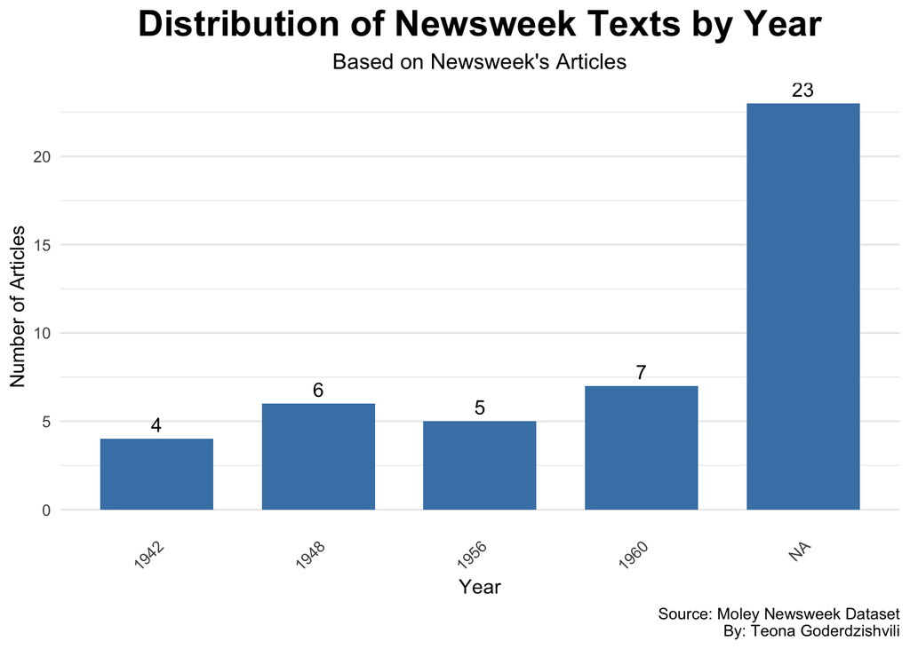